# New analysis SIP Palsa

Christian Ayala

7/27/2022

# Data Pre-processing

## 1. Setup

### Importing libraries

```r
library(tidyverse)
library(readxl)
library(ggpubr)
library(vegan)
library(rstatix)
library(factoextra)
library(pheatmap)
library(ComplexHeatmap)
source('new_analysis/functions_cdis_exploration.R')
source('new_analysis/functions_cdis_norm_stats.R')
source('new_analysis/functions_cdis_diff.R')
```

### Setting project folders

```r
#set path variables
project_dir <- 'new_analysis'

# Give a name for your project so the results are all grouped together in a directory with the same name
project_name <- 'palsa_7_25_22'
figures_dir <- file.path(project_dir, paste0(project_name, '_output_figures'))
tables_dir <- file.path(project_dir,  paste0(project_name, '_output_tables'))

# Create output directories
dir.create(figures_dir, showWarnings = FALSE)

dir.create(tables_dir, showWarnings = FALSE)
```

## 2. Loading data

```r
# Import data tables
cd_results_file <- file.path(project_dir,
                             '..',
                             'data',
                             'palsa_labeled_snt_3_int_2e6.xlsx')

cd_results_table <- read_xlsx(cd_results_file) %>%
  mutate(Name = ifelse(abs(`Annot. DeltaMass [ppm]`) > 5, NA, Name),
         Formula = ifelse(abs(`Annot. DeltaMass [ppm]`) > 5, NA, Formula)) %>%
  arrange(desc(`Calc. MW`)) %>%
  mutate(FeatureID = paste0('Feature',formatC(n():0001,
                                              width = 4,
                                              flag = '0'))) %>%
  select(FeatureID, Name, Formula, `Calc. MW`,
         contains('Annotation source'), contains('Results'),
         contains('Pathways'),
         contains('Area:'), contains('Gap Status:'),
         contains('Labeling Status:'), contains('Gap Fill Status:'),
         contains('Rel. Exchange')) %>%
  rename_with(function(.x){
    y <- str_remove(.x, 'Saleska_') %>%
      str_remove('_26Jan.*')
    return(y)
  }) %>%
  # Differentiate between features that share the same name using "peak#" at the end of the name
  group_by(Name) %>%
  add_count(Name) %>%
  # Create variable with names for plotting (useful in following scripts)
  mutate(name4plot = case_when(is.na(Name) ~ FeatureID,
                               n == 1 ~ Name,
                               TRUE ~  paste0(Name, '-peak', n():1))) %>%
  select(-n) %>%
  ungroup()

# Import metadata and fix names
metadata_file <- file.path(project_dir,
                           '..',
                           'data',
                           'metadata_palsa_labeled.csv')

metadata <- read_csv(metadata_file) %>%
  rename(SampleID = `Sample Identifier`,
         sample_type = `Sample Type`) %>%
  filter(type == 'incubation' | type == 'peat' | type == 'litter',
         !(time == 'T0' & type == 'peat')) %>%
  mutate(sample_type = str_replace(sample_type, 'Sample', 'Unlabeled'))

table_file <- file.path(tables_dir, 'fixed_metadata.csv')
write_csv(metadata, table_file)
```

## 3. Rearranging data and calculating indexes

### Separating label information

```r
label_status <- cd_results_table %>%
  select(FeatureID,
         contains('Labeling Status:'),
         contains('Rel. Exchange')) %>%
  pivot_longer(!FeatureID, names_to = c('.value', 'SampleID'),
               names_pattern = '(.*): (.*)')  %>%
  mutate(label_nw =
           case_when(`Labeling Status` == 'No warnings' &
                       `Rel. Exchange [%]` > 0.5 ~ 'Labeled',
                     `Labeling Status` == 'Not detected' ~ 'Not_detected',
                     TRUE ~ 'Non_labeled'),
         label_irreg =
           case_when((`Labeling Status` == 'No warnings' &
                        `Rel. Exchange [%]` > 0.5) |
                       (`Labeling Status` == 'Irregular exchange' &
                          `Rel. Exchange [%]` > 15) ~ 'Labeled',
                     `Labeling Status` == 'Not detected' ~ 'Not_detected',
                     TRUE ~ 'Non_labeled')) %>%
  mutate(label_nw = factor(label_nw,
                           levels = c('Not_detected',
                                      'Non_labeled',
                                      'Labeled')),
         label_irreg = factor(label_irreg,
                              levels = c('Not_detected',
                                         'Non_labeled',
                                         'Labeled')))


table_file <- file.path(tables_dir, 'label_status.csv')
write_csv(label_status, table_file)
```

### Abundance and chemical data

```r
# Split formula column into elemental counts
cd_results_table <- separate_formula(cd_results_table)

# Calculate ratios and thermodynamic indices
cd_results_table <- calc_ratios_n_idxs(cd_results_table)

# Calculate classes
cd_results_table <- calc_classes(cd_results_table)

# Gather area under the curve (AUC) values per sample

compounds_table <- cd_results_table %>%
  select(-contains('Gap Status:'), -contains('Labeling Status:'), -contains('Gap Fill Status:'),
         -contains('Rel. Exchange [%]:')) %>%
  pivot_longer(contains('Area:'), names_to = 'SampleID', values_to = 'AUC') %>%
  mutate(SampleID = str_remove(SampleID, 'Area: ')) %>%
  filter(AUC > 0) %>%
  right_join(metadata, by = 'SampleID') %>%
  left_join(label_status, by = c('FeatureID', 'SampleID')) %>%
  select(-`Labeling Status`, - `Rel. Exchange [%]`, -label_nw)

# Save gap-filled table to be used in Statistical Analysis

table_file <- file.path(tables_dir, 'compounds_table_with_label.csv')
write_csv(compounds_table, table_file)
```

#### Setting colors for treatments for all file

```r
sample_type_col <- get_palette(palette = 'Dark2', 2)
names(sample_type_col) <- unique(metadata$sample_type)

time_col <- get_palette(palette = 'nejm', 4)
names(time_col) <- unique(metadata$time)

type_col <- get_palette(palette = 'jco', 3)
names(type_col) <- unique(metadata$type)

class_col <- get_palette(palette = 'uchicago', 9)
names(class_col) <- unique(compounds_table$Class)
```

## 3. Checking which compounds are labeled

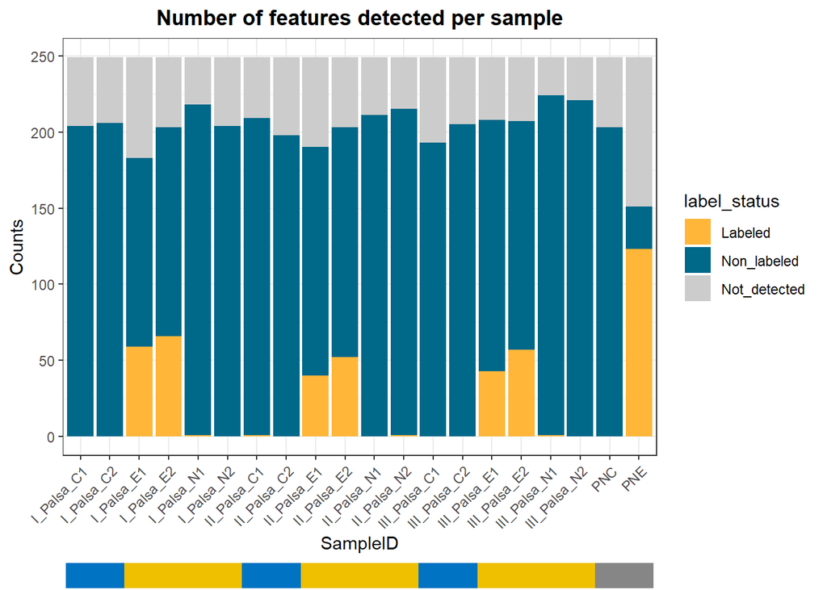

```r
label_plot <- label_status %>%
  pivot_longer(contains('label_'), names_to = 'detection',
               values_to = 'label_status') %>%
  filter(detection == 'label_irreg',
         SampleID != 'Palsa_T0') %>%
  group_by(SampleID, detection) %>%
  count(label_status) %>%
  ggplot() +
  geom_col(aes(x = SampleID,
               y = n,
               fill = label_status)) +
  scale_fill_manual(values = c(Labeled = '#ffb639',
                               Non_labeled = '#006889',
                               Not_detected = 'gray80')) +
  theme_bw() +
  labs(y = 'Counts',
       title = 'Number of features detected per sample') +
  theme(axis.text.x = element_text(angle = 45, hjust = 1),
        plot.title = element_text(face = 'bold', hjust = 0.5),
        plot.subtitle = element_text(face = 'italic', hjust = 0.5))

label_annot_bar <- label_status %>%
  filter(SampleID != 'Palsa_T0') %>%
  left_join(metadata, by = 'SampleID') %>%
  ggplot() +
  scale_fill_manual(values = type_col) +
  geom_tile(aes(x = SampleID,
                y = 1,
                fill = type)) +
  theme_void() +
  theme(legend.position = 'none')

label_plot_f <- cowplot::plot_grid(label_plot, label_annot_bar,
                                   nrow = 2,
                                   ncol = 1,
                                   align = 'v',
                                   axis = 'lr',
                                   rel_heights = c(20, 1))
label_plot_f
```

```r
figure_file <- file.path(figures_dir, 'label_status.png')
ggsave(figure_file, label_plot, dpi = 300)
```

# Statistical Analysis

## 5. Normalizing data

Not detected compounds are going to be assigned an intensity of 0

```r
auc_matrix <- compounds_table %>%
  select(FeatureID, SampleID, AUC) %>%
  pivot_wider(names_from = 'SampleID', values_from = 'AUC') %>%
  column_to_rownames(var = 'FeatureID')

auc_matrix[is.na(auc_matrix)] <- 0
```

Test normalization methods

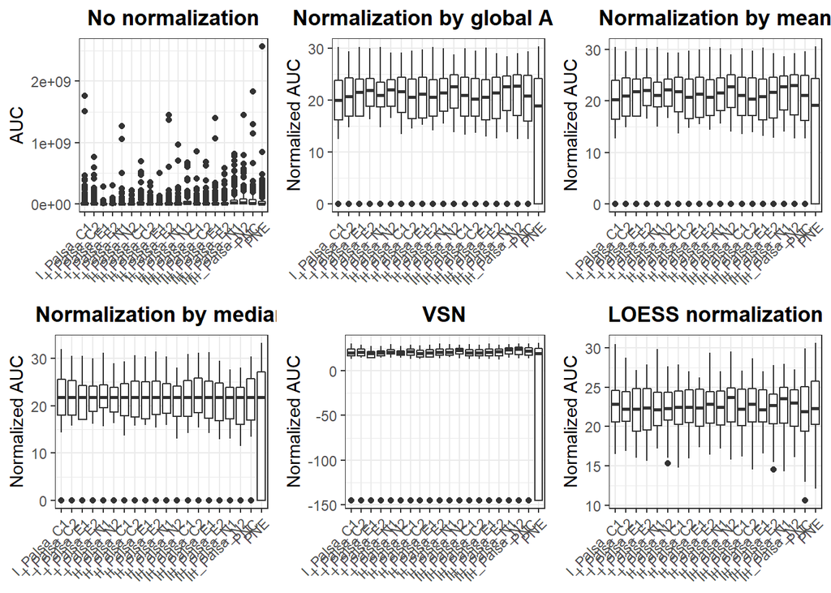

```r
normalization_plot <- normalize_by_all(auc_matrix)
normalization_plot
```

Normalizing data

```r
norm_matrix <- mean.norm(auc_matrix)
```

## 6. Multivariate Analysis

### NMDS

Calculating distance matrix

```r
t_norm_matrix <- t(norm_matrix[,3:20])
dm.method <- 'bray'
# distance matrix by Bray because relative abundance mode was selected
dm <- vegdist(t_norm_matrix, method=dm.method)
```

Performing NMDS analysis

```r
set.seed(123)
nmds <- metaMDS(dm,
                k = 2,
                maxit = 999,
                trymax = 500,
                wascores = TRUE)
```

```
## *** Solution reached
```

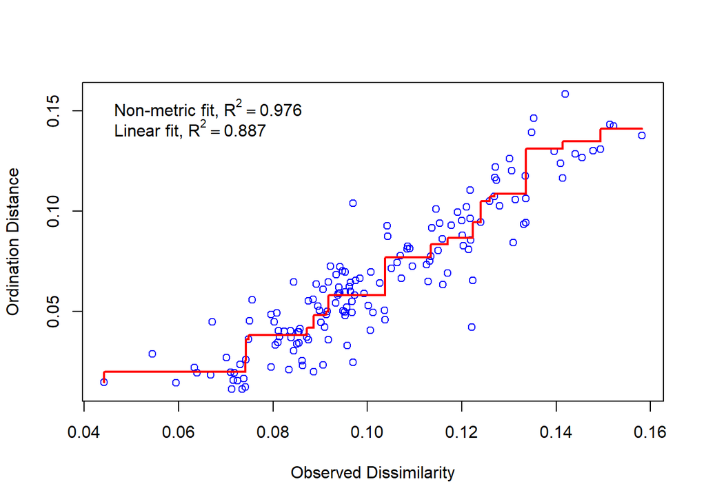

```r
stressplot(nmds)
```

Extracting NMDS scores and plotting

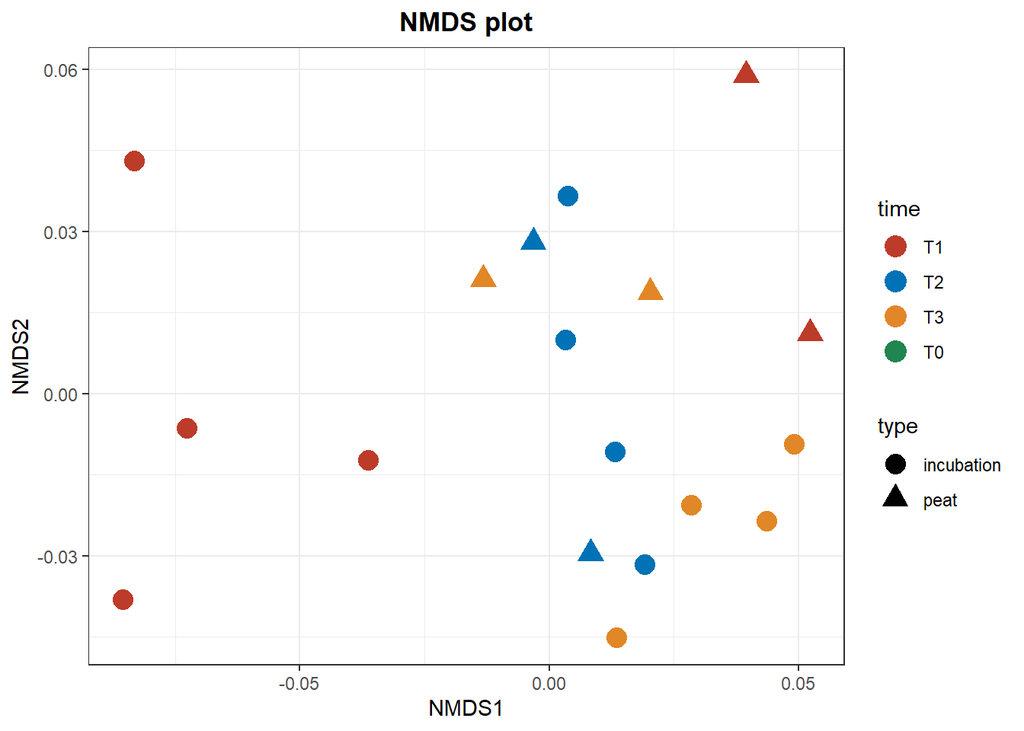

```r
nmds_scores <- as.data.frame(scores(nmds, display = 'sites')) %>%
  rownames_to_column(var = 'SampleID') %>%
  left_join(metadata, by = 'SampleID')

nmds_plot <- nmds_scores %>%
  filter(type != 'litter') %>%
  ggplot() +
  geom_point(aes(x = NMDS1,
                 y = NMDS2,
                 color = time,
                 shape = type),
             size = 4,
             stroke = 1) +
  scale_color_manual(values = time_col) +
  guides(fill = guide_legend(override.aes = list(shape = 21, color = NA))) +
  labs(title = 'NMDS plot') +
  theme_bw() +
  theme(plot.title = element_text(face = 'bold', hjust = 0.5))
nmds_plot
```

```r
figure_file <- file.path(figures_dir, 'nmds_relative_abundance.png')
ggsave(figure_file, nmds_plot, dpi = 300)
```

### PCA

Calculating PCA eigenvalues and plotting scree plot

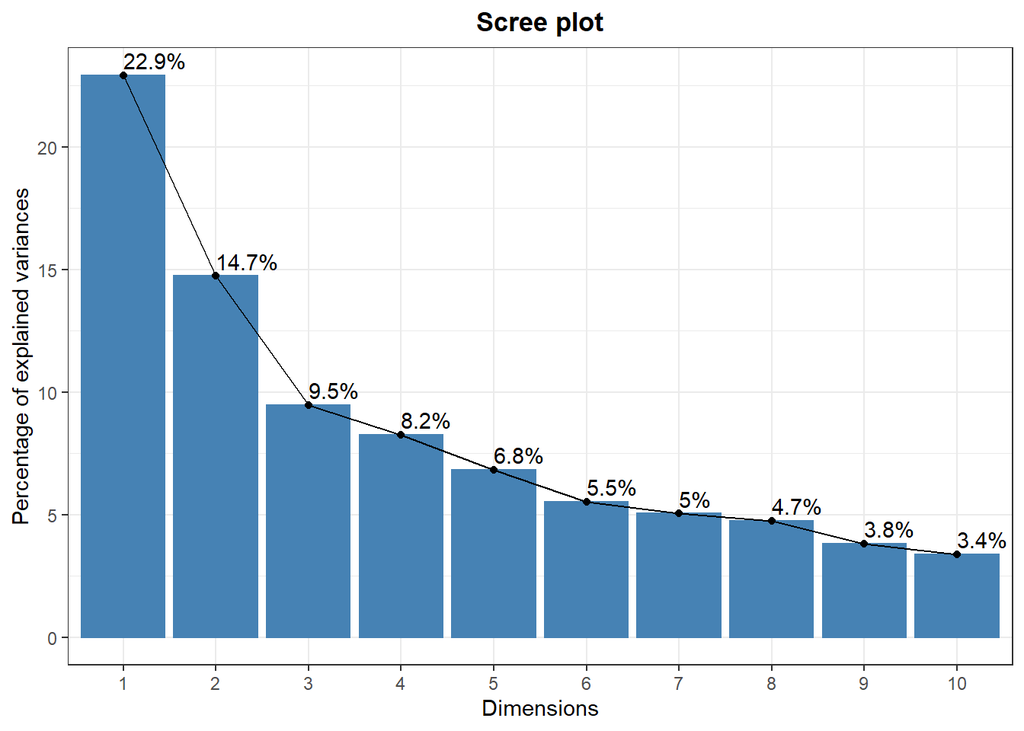

```r
pca <- prcomp(t_norm_matrix)
# Get eigenvalues
eigen <- get_eigenvalue(pca)

scree_plot <- fviz_eig(pca, addlabels = TRUE) +
  theme_bw() +
  theme(plot.title = element_text(face = 'bold', hjust = 0.5))
scree_plot
```

```r
figure_file <- file.path(figures_dir, 'screeplot.png')
ggsave(figure_file, scree_plot, dpi = 300)
```

Extracting PCA coordinates and plotting

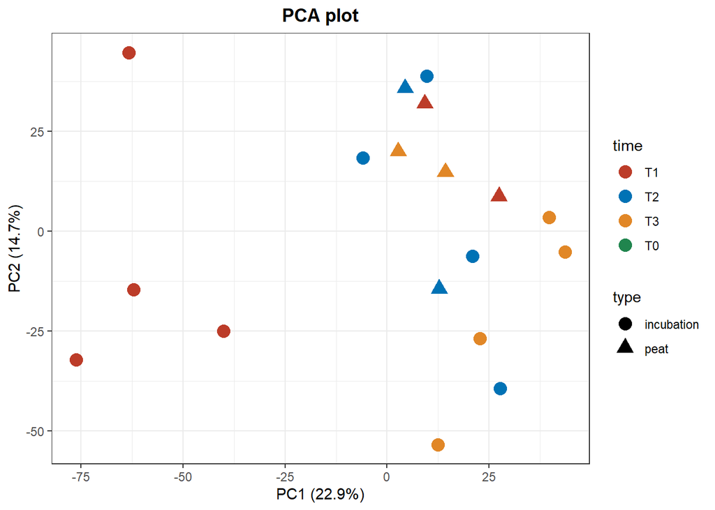

```r
pca_coordinates <- as.data.frame(pca$x) %>%
  rownames_to_column(var = 'SampleID') %>%
  left_join(metadata, by ='SampleID')

# Prepare axis labels for PCA

pc1 <- paste0('PC1 (', round(eigen$variance.percent[1], digits = 1), '%)')
pc2 <- paste0('PC2 (', round(eigen$variance.percent[2], digits = 1), '%)')

# Plot Individuals PCA

pca_plot <- pca_coordinates %>%
  ggplot() +
  geom_point(aes(x = PC1,
                 y = PC2,
                 color = time,
                 shape = type),
             size = 4) +
  scale_color_manual(values = time_col) +
  guides(fill = guide_legend(override.aes = list(shape = 21, color = NA))) +
  labs(title = 'PCA plot',
       x = pc1,
       y = pc2) +
  theme_bw() +
  theme(plot.title = element_text(face = 'bold', hjust = 0.5))


pca_plot
```

```r
figure_file <- file.path(figures_dir, 'PCA-plot.png')
ggsave(figure_file, pca_plot, dpi = 300)
```

### PERMANOVA

```r
metadata_filt <- metadata %>%
  filter(type != 'litter')
rownames(metadata_filt) <- metadata_filt$SampleID

set.seed(456)
permanova <- adonis2(dm ~ time + type + sample_type,
                     data=metadata_filt,
                     permutations=999,
                     method="bray")
permanova %>%
  knitr::kable() %>%
  kableExtra::kable_styling(bootstrap_options = c("striped", "hover"))
```

|  | Df | SumOfSqs | R2 | F | Pr(>F) |
| --- | --- | --- | --- | --- | --- |
| time | 2 | 0.0093238 | 0.1015500 | 0.9162824 | 0.566 |
| type | 1 | 0.0090689 | 0.0987732 | 1.7824558 | 0.065 |
| sample_type | 1 | 0.0072803 | 0.0792931 | 1.4309184 | 0.184 |
| Residual | 13 | 0.0661422 | 0.7203837 | NA | NA |
| Total | 17 | 0.0918152 | 1.0000000 | NA | NA |

## 7. Differential abundance analysis

### Sample-to-sample distances

This heatmap intends to provide an overview of sample similarities or dissimilarities

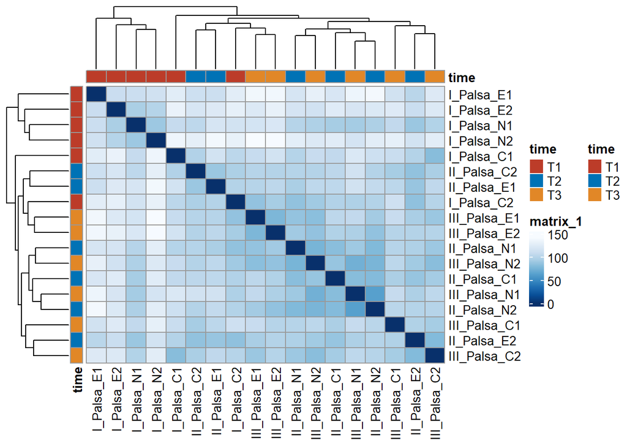

```r
dist_samples <- dist(t_norm_matrix)
dist_matrix <- as.matrix(dist_samples)

hmp_annot_df <- metadata_filt %>%
  select(SampleID, time) %>%
  column_to_rownames(var = 'SampleID')

hmp_annot_colors <- list(time = time_col,
                         sample_type = sample_type_col)

pheatmap(dist_matrix,
         clustering_distance_rows = dist_samples,
         clustering_distance_cols = dist_samples,
         annotation_row = hmp_annot_df,
         annotation_col = hmp_annot_df,
         annotation_colors = hmp_annot_colors,
         color = colorRampPalette(rev(get_palette('Blues', 10)))(100))
```

### Getting samples lists

```r
treatments_df <- metadata %>%
  select(time, type) %>%
  distinct %>%
  unite(t_name, time, type, sep = '_', remove = FALSE) %>%
  mutate(t_name = ifelse(type == 'litter', 'T0_litter', t_name))

sample_lists <- pmap(list(treatments_df$time,
                          treatments_df$type),
                     function(y, z){

                       if(z == 'litter'){
                         metadata %>%
                           filter(type == z) %>%
                           pull(SampleID)
                       } else {
                         metadata %>%
                           filter(time == y,
                                  type == z) %>%
                           pull(SampleID)
                       }

                     })
names(sample_lists) <- treatments_df$t_name

samples_peat <- sample_lists[str_detect(names(sample_lists), 'peat')]
samples_inc <- sample_lists[str_detect(names(sample_lists), 'incubation')]
```

### Calculate differential expression

Getting a list of labeled samples in each treatment

```r
label_lists <- map(sample_lists, function(x){
  unique(compounds_table %>%
           filter(SampleID %in% x,
                  label_irreg == 'Labeled') %>%
           pull(FeatureID))
})

label_inc <- label_lists[str_detect(names(label_lists), 'incubation')]
```

#### **Against peat T1**

Differential expression will be calculated by comparing each time point (labeled and unlabeled) with the peat at T1

```r
diff_exp_tables <- map(samples_inc, function(x){
  diff <- get_diff_table(norm_matrix,
                         control.sample_list = samples_peat$T1_peat,
                         treatment.sample_list = x,
                         log2_transformed = TRUE) %>%
    mutate(Expression = ifelse(log2FC > 0, 'Upregulated', 'Downregulated'))
  fdrtool_res <- fdrtool::fdrtool(diff$pval, statistic = 'pvalue', plot = FALSE)
  diff$fdrtool_pvalue <- fdrtool_res$pval
  diff$fdrtool_qval <- fdrtool_res$qval
  return(diff)
})
```

```r
volcanos <- imap(diff_exp_tables, function(x, y){
  plot_volcano(x,
               log2FC,
               fdrtool_qval,
               log2FC.threshold = 1,
               pval.threshold = 0.1,
               search_label = TRUE,
               label_ids_control = label_lists$T0_litter,
               label_ids_treatment = y) +
    labs(title = paste0(y, ' vs peat'))
})
```

Using the labeled and unlabeled samples together as replicates, helps to find statistically significant differences, that did not appeared before.

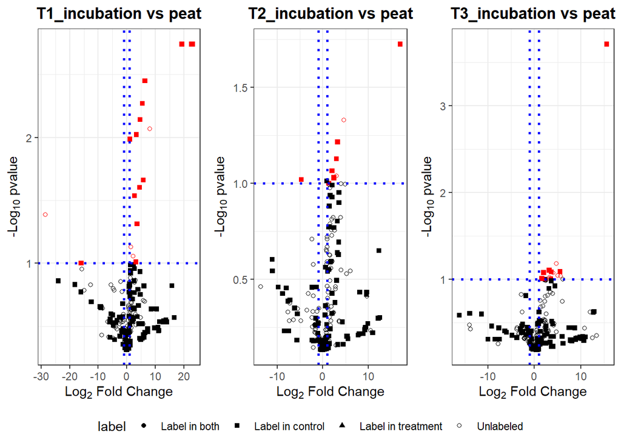

```r
p_list <- volcanos[c(1,3)]

with_t1_peat <- ggarrange(plotlist = volcanos, common.legend = TRUE,
                          legend = 'bottom', nrow = 1)
with_t1_peat
```

```r
figure_file <- file.path(figures_dir, 'Comparisons_with_t1_peat.png')
ggsave(figure_file, with_t1_peat, dpi = 300, width = 12, bg = 'white')
diff_exp_sig_labeled <- map2(diff_exp_tables, label_inc, function(x, y){

  comp_temp <- compounds_table %>%
    select(FeatureID, Name, Formula, `Calc. MW`, Class) %>%
    distinct()

  res <- x %>%
    filter(pval.adj <= 0.1) %>%
    mutate(label = case_when(
      (FeatureID %in% label_lists$T0_litter) &
        (FeatureID %in% y) ~ 'Label in both',
      FeatureID %in% label_lists$T0_litter ~ 'Label in control',
      FeatureID %in% y ~ 'Label in treatment',
      TRUE ~ 'Unlabeled')) %>%
    filter(label != 'Unlabeled') %>%
    left_join(comp_temp, by = 'FeatureID')
})

iwalk(diff_exp_sig_labeled, function(x, y){
  filename <- file.path(tables_dir, paste0('Diff_df_', y, '_against_peat_T1.csv'))
  write_csv(x, filename)
})
```

```r
names <- names(diff_exp_sig_labeled)
plot_bar <- map2(diff_exp_sig_labeled, names,
                 function(x, y){
                   x %>%
                     mutate(Expression = factor(Expression,
                                                levels = c('Upregulated', 'Downregulated'))) %>%
                     group_by(Expression) %>%
                     count(Class) %>%
                     ggplot() +
                     geom_col(aes(x = Class,
                                  y = n,
                                  fill = Expression),
                              position = position_dodge()) +
                     labs(title = y) +
                     facet_grid(cols = vars(Expression),
                                scales = 'free_x',
                                space = 'free_x') +
                     scale_fill_manual(values = get_palette('RdBu', 2)) +
                     theme_bw() +
                     theme(plot.title = element_text(face = 'bold',
                                                     hjust = 0.5),
                           axis.text.x = element_text(angle = 45,
                                                      hjust = 1))
                 })
```

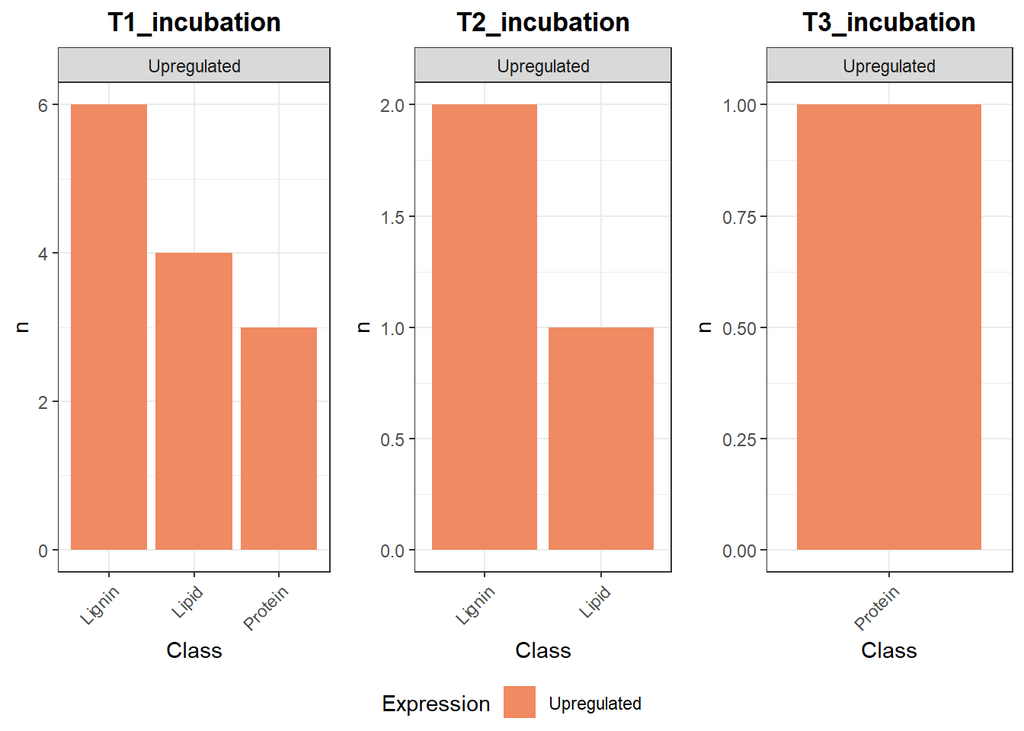

```r
bars <- ggarrange(plotlist = plot_bar,
                  nrow = 1,
                  align = 'h',
                  common.legend = TRUE,
                  legend = 'bottom')
bars
```

```r
figure_file <- file.path(figures_dir, 'classes_with_t1_peat.png')
ggsave(figure_file, bars, dpi = 300, width = 8, bg = 'white')
```

#### **Against litter**

```r
diff_exp_tables <- map(samples_inc, function(x){
  diff <- get_diff_table(norm_matrix,
                         control.sample_list = sample_lists$T0_litter,
                         treatment.sample_list = x,
                         log2_transformed = TRUE) %>%
    mutate(Expression = ifelse(log2FC > 0, 'Upregulated', 'Downregulated'))
  fdrtool_res <- fdrtool::fdrtool(diff$pval, statistic = 'pvalue', plot = FALSE)
  diff$fdrtool_pvalue <- fdrtool_res$pval
  diff$fdrtool_qval <- fdrtool_res$qval
  return(diff)
})
```

```r
volcanos <- pmap(list(diff_exp_tables, label_inc, names(label_inc)),
                 function(x, y, z){
                   plot_volcano(x,
                                log2FC,
                                pval.adj,
                                log2FC.threshold = 1,
                                pval.threshold = 0.1,
                                search_label = TRUE,
                                label_ids_control = label_lists$T0_litter,
                                label_ids_treatment = y) +
                     labs(title = paste0(z, ' vs litter'))
                 })
```

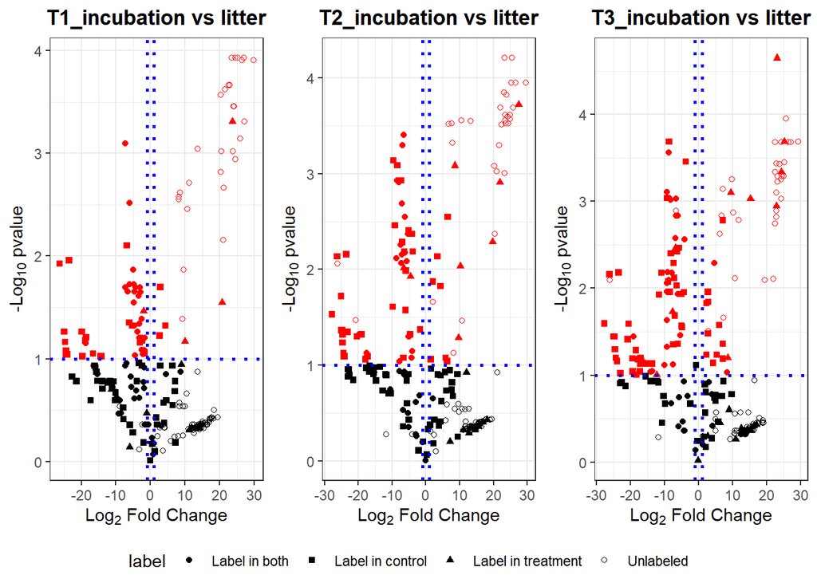

```r
l_list <- volcanos[c(1,3)]
with_litter <- ggarrange(plotlist = volcanos, common.legend = TRUE,
                         nrow = 1,
                         legend = 'bottom')
with_litter
```

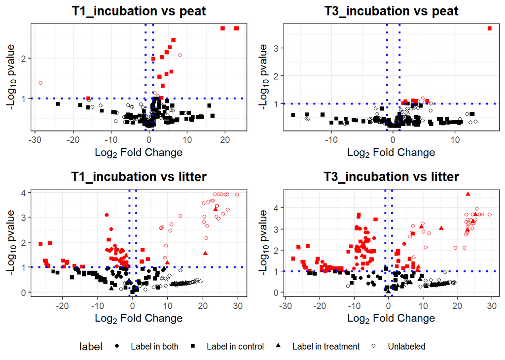

```r
figure_file <- file.path(figures_dir, 'Comparisons_with_litter_peat.png')
ggsave(figure_file, with_litter, dpi = 300, width = 12, bg = 'white')
combined <- ggarrange(plotlist = c(p_list, l_list),
                      nrow = 2, ncol = 2,
                      common.legend = TRUE,
                      legend = 'bottom')

combined
```

Get table of significantly differentially expressed labeled compounds (*p-value* < 0.1)

```r
diff_exp_sig_labeled <- map2(diff_exp_tables, label_inc, function(x, y){

  comp_temp <- compounds_table %>%
    select(FeatureID, Name, Formula, `Calc. MW`, Class) %>%
    distinct()

  res <- x %>%
    filter(pval.adj < 0.1) %>%
    mutate(label = case_when(
      (FeatureID %in% label_lists$T0_litter) &
        (FeatureID %in% y) ~ 'Label in both',
      FeatureID %in% label_lists$T0_litter ~ 'Label in control',
      FeatureID %in% y ~ 'Label in treatment',
      TRUE ~ 'Unlabeled')) %>%
    filter(label != 'Unlabeled') %>%
    left_join(comp_temp, by = 'FeatureID')
})

iwalk(diff_exp_sig_labeled, function(x, y){
  filename <- file.path(tables_dir, paste0('Diff_df_', y, '_against_litter.csv'))
  write_csv(x, filename)
})
```

Most of the significantly differentially expressed compounds that are labeled have no annotation, thus below I am checking their molecular class

#### Heatmap of normalized abundances

**Create color vector**

```r
htm_col <- circlize::colorRamp2(seq(0, 32, 4),
                                viridis::inferno(9,
                                                 direction = -1,
                                                 begin = 0.2,
                                                 end = 0.8))
```

**Create annotations**

```r
col_annot_df <- metadata %>%
  select(SampleID, type, time) %>%
  arrange(time) %>%
  column_to_rownames(var = 'SampleID')

row_annot_df <- compounds_table %>%
  select(FeatureID, NOSC, GFE, Class, `Calc. MW`) %>%
  distinct() %>%
  arrange(FeatureID) %>%
  column_to_rownames(var = 'FeatureID')

ca1 <- columnAnnotation(df = col_annot_df,
                         col = list(type = type_col,
                                    time = time_col))

ra1 <- rowAnnotation(NOSC = anno_lines(row_annot_df$NOSC),
                     annotation_name_side = 'top')
ra2 <- rowAnnotation(df = select(row_annot_df, Class),
                     col = list(Class = class_col))
```

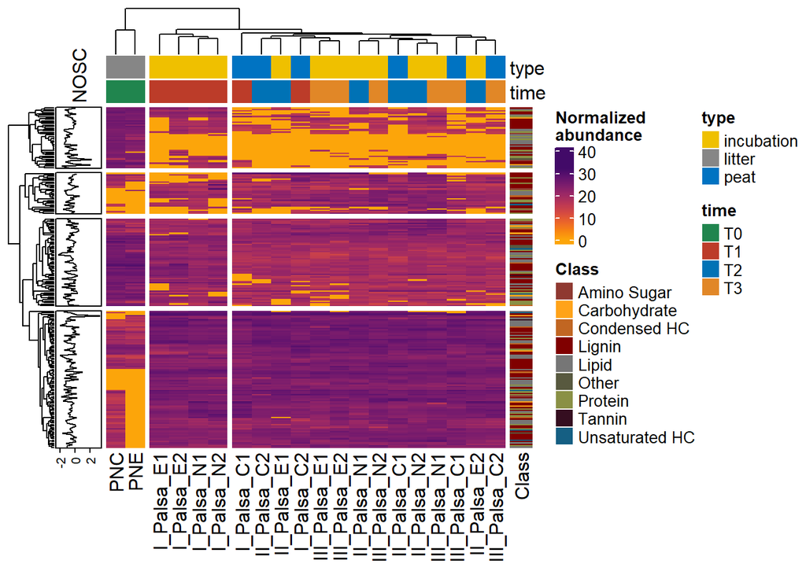

```r
norm_matrix_ord <- norm_matrix[rownames(row_annot_df), rownames(col_annot_df)]

Heatmap(norm_matrix_ord,
        col = htm_col,
        name = 'Normalized\nabundance',
        row_split = 4,
        column_split = 3,
        column_title = NULL,
        row_title = NULL,
        show_row_names = FALSE,
        top_annotation = ca1,
        left_annotation = ra1,
        right_annotation = ra2
)
```

#### Molecular class of differentially abundant metabolites

```r
names <- names(diff_exp_sig_labeled)
plot_bar <- map2(diff_exp_sig_labeled, names,
                 function(x, y){
                   x %>%
                     mutate(Expression = factor(Expression,
                                                levels = c('Upregulated', 'Downregulated'))) %>%
                     group_by(Expression) %>%
                     count(Class) %>%
                     ggplot() +
                     geom_col(aes(x = Class,
                                  y = n,
                                  fill = Expression),
                              position = position_dodge()) +
                     labs(title = y) +
                     facet_grid(cols = vars(Expression),
                                scales = 'free_x',
                                space = 'free_x') +
                     scale_fill_manual(values = get_palette('RdBu', 2)) +
                     theme_bw() +
                     theme(plot.title = element_text(face = 'bold',
                                                     hjust = 0.5),
                           axis.text.x = element_text(angle = 45,
                                                      hjust = 1))
                 })
```

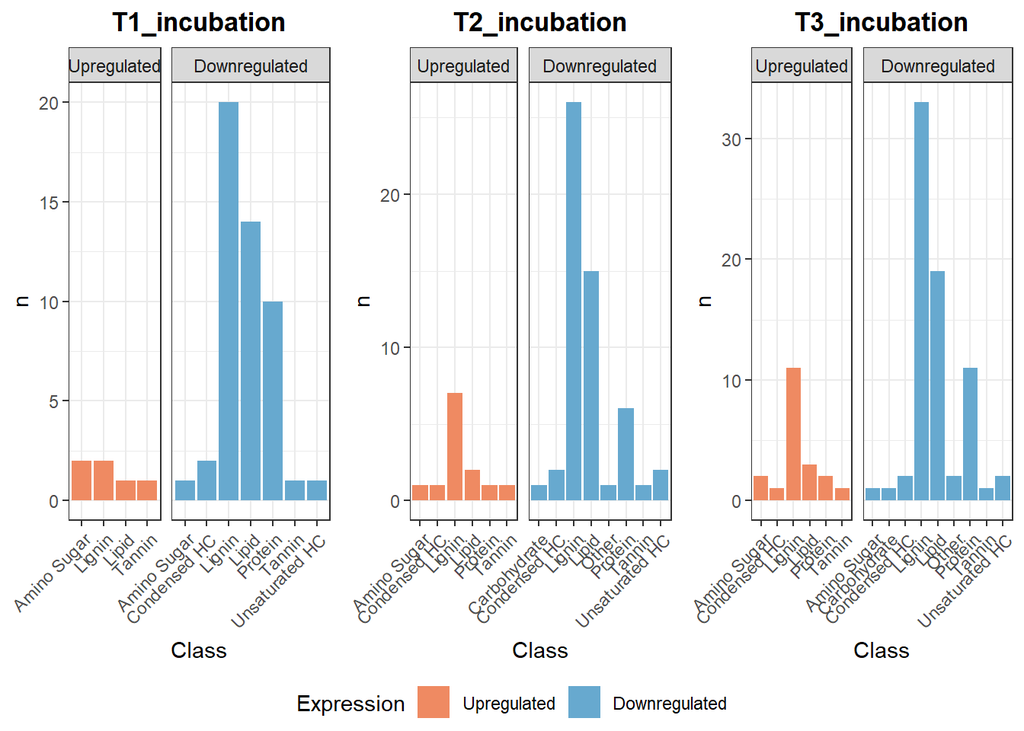

```r
bars <- ggarrange(plotlist = plot_bar,
                  align = 'h',
                  nrow = 1,
                  common.legend = TRUE,
                  legend = 'bottom')
bars
```

```r
figure_file <- file.path(figures_dir, 'classes_with_litter.png')
ggsave(figure_file, bars, dpi = 300, width = 8, bg = 'white')
```

## 8. Individual figures

```r
norm_abundance_long <- norm_matrix %>%
  rownames_to_column(var = 'FeatureID') %>%
  pivot_longer(!FeatureID, names_to = 'SampleID', values_to = 'norm_abundance') %>%
  filter(norm_abundance > 0) %>%
  left_join(metadata, by = 'SampleID')

selected_features <- norm_abundance_long %>%
  group_by(FeatureID, type, time) %>%
  summarise(mean_norm = mean(norm_abundance)) %>%
  mutate(type2 = ifelse(type == 'litter', 'incubation,peat', type)) %>%
  separate_rows(type2, sep = ',') %>%
  filter(FeatureID == 'Feature0036' |
           FeatureID == 'Feature0026' |
           FeatureID == 'Feature0109' |
           FeatureID == 'Feature0004')
```

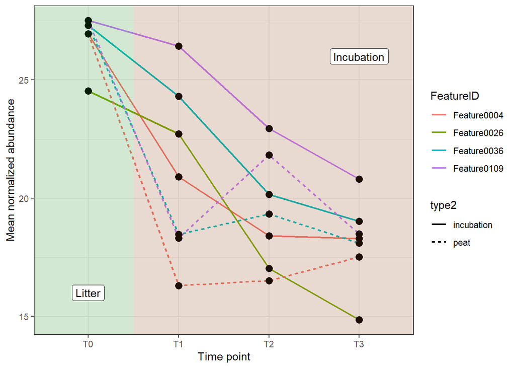

```r
plot_features <- selected_features %>%
  unite(group, type2, FeatureID, sep = '_', remove = FALSE) %>%
  ggplot() +
  geom_line(aes(x = time,
                y = mean_norm,
                group = group,
                color = FeatureID,
                linetype = type2),
            size = .8) +
  geom_point(aes(x = time,
                 y = mean_norm),
             size = 3) +
  annotate('rect',
           xmin = c(-Inf, 1.5),
           xmax = c(1.5, Inf),
           ymin = c(-Inf, -Inf),
           ymax = c(Inf, Inf),
           alpha = .2,
           fill = c('forestgreen', 'chocolate4')) +
  annotate('label', x = c(1, 4), y = c(16, 26), label = c('Litter', 'Incubation')) +
  labs(x = 'Time point',
       y = 'Mean normalized abundance') +

  theme_bw()

plot_features
```

```r
selected_features <- norm_abundance_long %>%
  group_by(FeatureID, type, time) %>%
  summarise(mean_norm = mean(norm_abundance)) %>%
  mutate(type2 = ifelse(type == 'litter', 'incubation,peat', type)) %>%
  separate_rows(type2, sep = ',') %>%
  filter(FeatureID == 'Feature0089' |
           FeatureID == 'Feature0013' |
           FeatureID == 'Feature0138' |
           FeatureID == 'Feature0044')
```

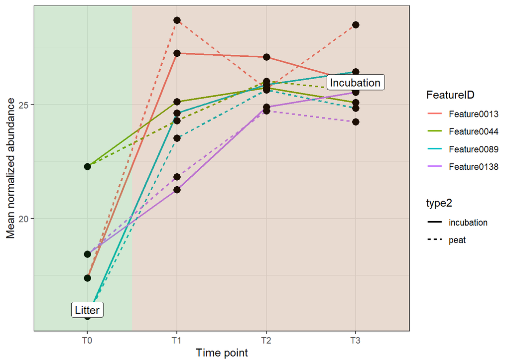

```r
plot_features <- selected_features %>%
  unite(group, type2, FeatureID, sep = '_', remove = FALSE) %>%
  ggplot() +
  geom_line(aes(x = time,
                y = mean_norm,
                group = group,
                color = FeatureID,
                linetype = type2),
            size = .8) +
  geom_point(aes(x = time,
                 y = mean_norm),
             size = 3) +
  annotate('rect',
           xmin = c(-Inf, 1.5),
           xmax = c(1.5, Inf),
           ymin = c(-Inf, -Inf),
           ymax = c(Inf, Inf),
           alpha = .2,
           fill = c('forestgreen', 'chocolate4')) +
  annotate('label', x = c(1, 4), y = c(16, 26), label = c('Litter', 'Incubation')) +
  labs(x = 'Time point',
       y = 'Mean normalized abundance') +

  theme_bw()

plot_features
```